# Культура работы с данными: лекция 2

## Основы теории вероятностей

#### Событие

1. Достоверное
2. Невозможное
3. Случайное

Совместные события - те, которые могут произойти одновременно. Полная группа событий - набор таких несовместных событий, что в результате опыта хоть одно из них обязательно произойдет.

Математическая логика - математическая теория для представления определенных высказываний.

```python
True or True, True and True
```

```
(True, True)
```

```python
True or False, True and False
```

```
(True, False)
```

Теория вероятностей - математическая теория для представления неопределенных высказываний.

```python
matching
```

|  | Логика | ТВ |
| --- | --- | --- |
| 0 | конъюнкция | пересечение множеств |
| 1 | дизъюнкция | объединение множеств |
| 2 | отрицание | дополнение |

### Что такое вероятность?

Два подхода к интерпретации понятия вероятности:

1. Частота события в большом количестве похожих ситуаций
2. Выражение субъективного верования

$$ P(A) = \frac{A\ happens}{(A\ happens) + (A\ does\ not\ happen)} $$

### Аксиомы Колмогорова

Для использования теории вероятностей нам нужны следующие вещи:

Множество элементарных событий $$ \Omega $$

Множество всех подмножеств множества элементарных событий $$ F $$

Отображение F на [0,1] $$ P $$

##### Аксиома 1

F содержит пустое множество, для каждой пары подмножеств МЭС содержит их объединение, для каждого подмножества МЭС содержит его дополнение, то есть является алгеброй событий.

##### Аксиома 2

$$ P(\Omega) = 1 $$

##### Аксиома 3

Для пары A, B несовместных событий: $$ P(A + B) = P(A) + P(B) $$

Выполнения этих требований достаточно для использования теории вероятности в задаче. Требования Колмогорова непротиворечивы, но неполны. Можно выбрать для одной и той же задачи разные определения вероятности.

### Парадокс Бертрана

Рассмотрим равносторонний треугольник, вписанный в окружность. Наудачу выбирается хорда окружности. Какова вероятность того, что выбранная хорда длиннее стороны треугольника?

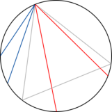

```python
Image("Bertrand1-figure.svg.png")
```

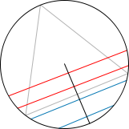

```python
Image("161px-Bertrand2-figure.svg.png")
```

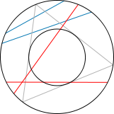

```python
Image("161px-Bertrand3-figure.svg.png")
```

### Сложение вероятностей

$$ P(A+B) = P(A) + P(B) - P(A\times B) $$

### Умножение вероятностей

A, B - независимые события: $$ P(A\times B) = P(A) \times P(B) $$

### Условная вероятность

$$ P(A|B) = \frac{P(A \times B)}{P(B)} $$

### Парадокс Монти-Холла

Есть три двери. За одной - автомат по курсу. За двумя другими два балла из десяти по всем домашним заданиям.

Я знаю, где автомат, а где пары.

Вы выбрали одну из дверей, а я открыл одну из оставшихся, ту, что с двумя баллами.

Увеличатся ли ваши шансы на автомат, если вы поменяете выбор?

### Формула полной вероятности

$$ P(A) = \sum_i P(A|B_i)P(B_i) $$

### Теорема Байеса

$$ P(A|B) = \frac{P(A|B)P(B)} {\sum_i P(B|A_i)P(A_i)} $$